# Finding the Best Model for Diabetes Prediction

Ching Yi Lam

12/11/2024

# Agenda

1. Introduction
2. Practical Questions to Address
3. Candidate Models and Justifications
4. Model Selection
5. Results
6. Conclusion
7. Limitations

# Introduction

- Finding the best model for predicting diabetes
- Which variable(s) is/are the best for this model
- This dataset has 100000 records and 9 variables
- No missing value

# Practical Questions to Address

1. Is the gender correlated to diabetes?
2. Is age correlated to diabetes? If age will be a possible chance to cause diabetes such as if the person is older, will tat cause a higher chance to have diabetes?
3. Is history of heart disease correlated to diabetes?
4. Is smoking history correlated to diabetes?
5. Is it possible that higher BMI, the higher chance to have diabetes?
6. Is blood glucose level correlated to diabetes?

# Summary of the Variables

```
##     gender           age         hypertension     heart_disease
##  Female:58552   Min.   : 0.08   Min.   :0.00000   Min.   :0.00000
##  Male  :41430   1st Qu.:24.00   1st Qu.:0.00000   1st Qu.:0.00000
##  Other :   18   Median :43.00   Median :0.00000   Median :0.00000
##                 Mean   :41.89   Mean   :0.07485   Mean   :0.03942
##                 3rd Qu.:60.00   3rd Qu.:0.00000   3rd Qu.:0.00000
##                 Max.   :80.00   Max.   :1.00000   Max.   :1.00000
##     smoking_history       bmi         HbA1c_level    blood_glucose_level
##  current    : 9286   Min.   :10.01   Min.   :3.500   Min.   : 80.0
##  ever       : 4004   1st Qu.:23.63   1st Qu.:4.800   1st Qu.:100.0
##  former     : 9352   Median :27.32   Median :5.800   Median :140.0
##  never      :35095   Mean   :27.32   Mean   :5.528   Mean   :138.1
##  No Info    :35816   3rd Qu.:29.58   3rd Qu.:6.200   3rd Qu.:159.0
##  not current: 6447   Max.   :95.69   Max.   :9.000   Max.   :300.0
##     diabetes
##  Min.   :0.000
##  1st Qu.:0.000
##  Median :0.000
##  Mean   :0.085
##  3rd Qu.:0.000
##  Max.   :1.000
```

# Checking Normality

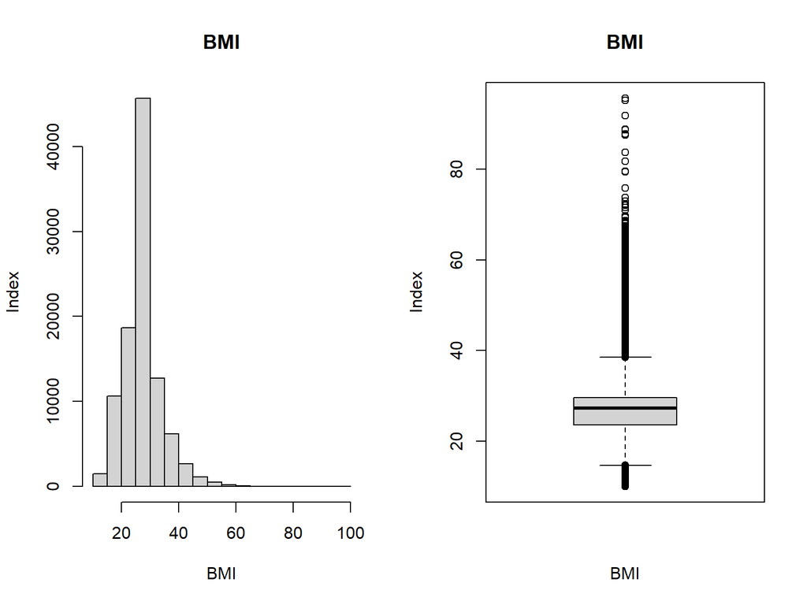

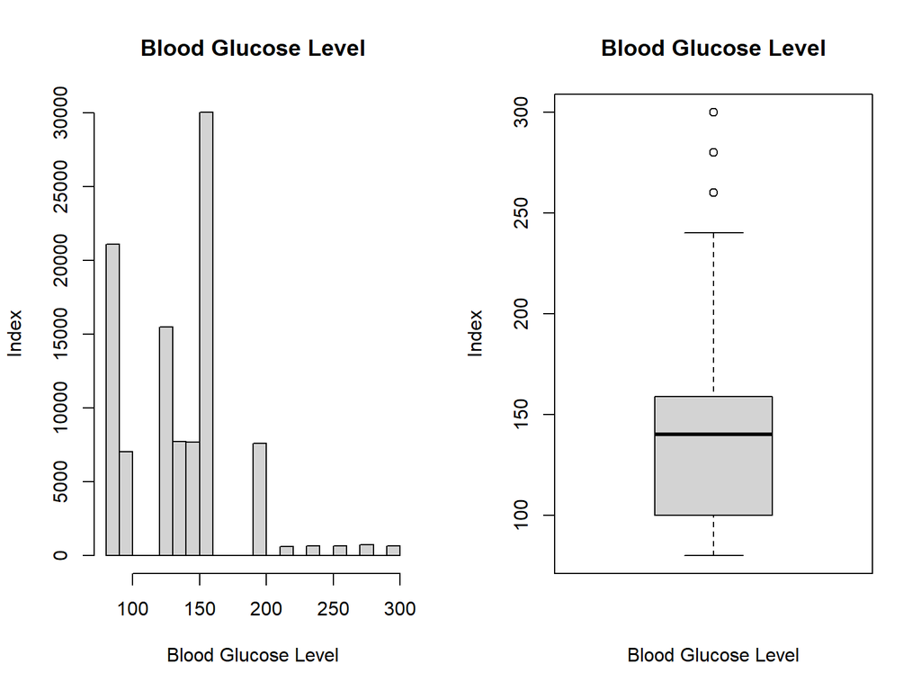

- The boxplots of BMI and blood glucose level are skewed to the right.
- We will use min-max scaling method to scale the numerical variables.

# Logistic Regression Analysis

- Finding the best candidate model using logistic regression analysis

Response variable: Diabetes

Predictor variables:

- Gender
- Age
- Hypertension
- Heart Disease
- Smoking History
- BMI
- HbA1c Level
- Blood Glucose Level

# Candidate Models

Here is the summary table for our model.

Summary table of significant tests

|  | Estimate | Std. Error | z value | Pr(>\|z\|) |
| --- | --- | --- | --- | --- |
| (Intercept) | -27.2069189 | 0.2975222 | -91.444995 | 0 |
| genderID | 0.2547450 | 0.0357809 | 7.119580 | 0 |
| age | 0.0467033 | 0.0011011 | 42.416603 | 0 |
| hypertension | 0.7752688 | 0.0469402 | 16.516104 | 0 |
| heart_disease | 0.7295988 | 0.0604112 | 12.077210 | 0 |
| smoking_historyID | -0.1251983 | 0.0130490 | -9.594444 | 0 |
| bmi | 0.0909407 | 0.0025421 | 35.774315 | 0 |
| HbA1c_level | 2.3391997 | 0.0356496 | 65.616392 | 0 |
| blood_glucose_level | 0.0333663 | 0.0004805 | 69.439066 | 0 |

- We used backward selection to choose the best candidate model.
- All of the variables are significant in predicting the response variable: diabetes.

# Predictive Analysis

- Use the best model that we found in logistic regression analysis to predict the successful introduction for 2 individuals.

Predicted Value of response variable with the given cut-off probability

| genderID | age | hypertension | heart_disease | smoking_historyID | bmi | HbA1c_level | blood_glucose_level | Pred.Response |
| --- | --- | --- | --- | --- | --- | --- | --- | --- |
| 1 | 25 | 0 | 1 | 3 | 25.25 | 8.0 | 165 | 1 |
| 2 | 68 | 1 | 0 | 4 | 31.75 | 3.5 | 85 | 0 |

- Used random value for the prediction.
- The predicted status of successful introduction showed above.

# Justification

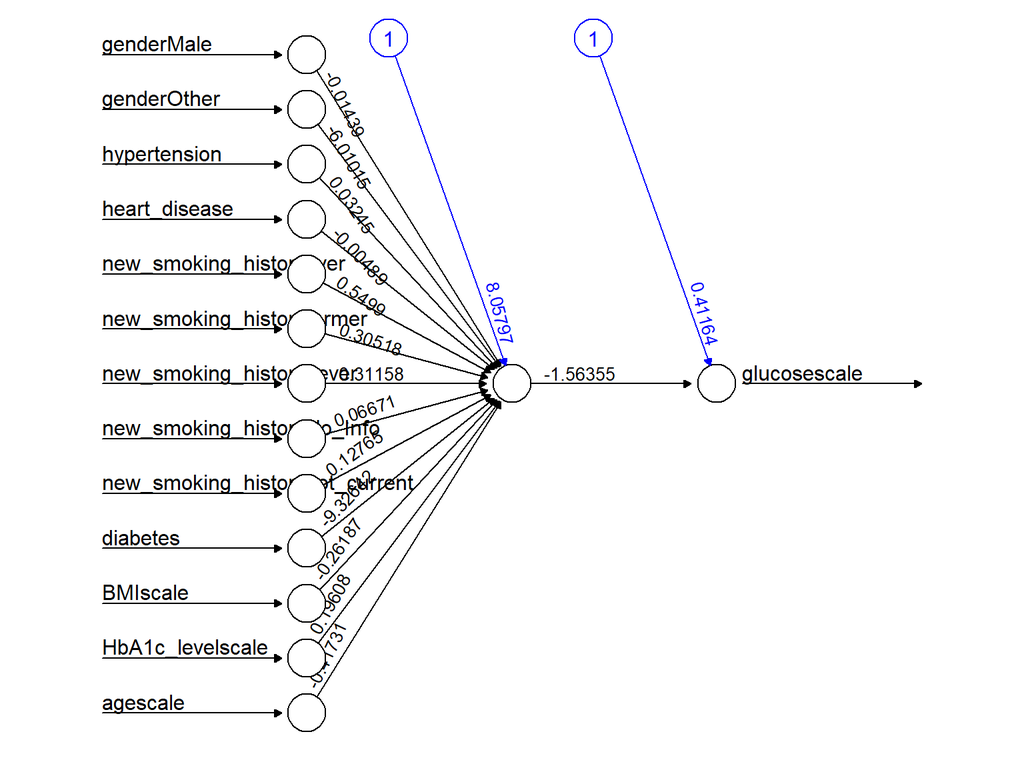

# Prediction and ROC Analysis for Logistic and Preceptron

- Construct the ROC curve for the perceptron model.
- Check the corresponding AUCs among the logistic prediction models and the perceptron model.

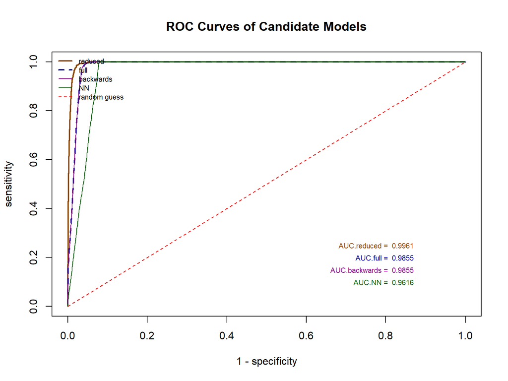

- Reduced model is the best model.
- Performance of reduced model = 0.9961, closest to 1.

# Decision Tree Algorithms

- ROC analysis for decision tree algorithms.
- Creating 6 different models.

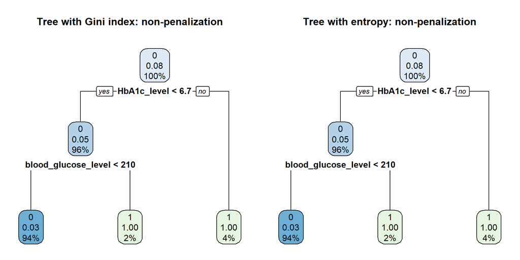

Non-penalized decision tree models using Gini index (left) and entropy (right)

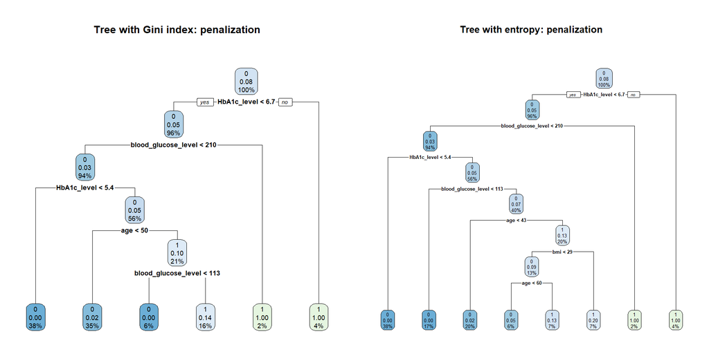

Penalized decision tree models using Gini index (left) and entropy (right)

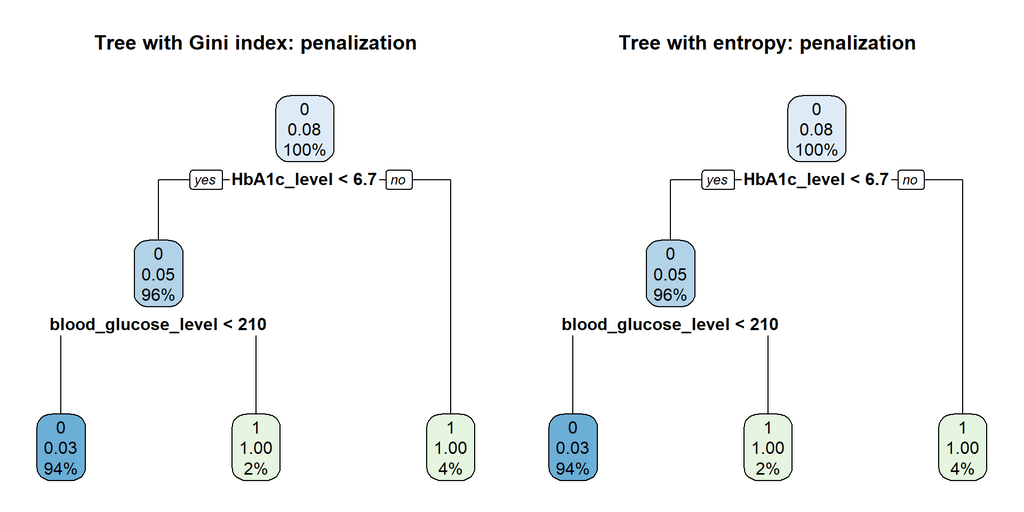

Penalized decision tree models using Gini index (left) and entropy (right)

# Model Selection for Descision Tree Algorithms

- This ROC curves represent various decision tree and their corresponding AUC.

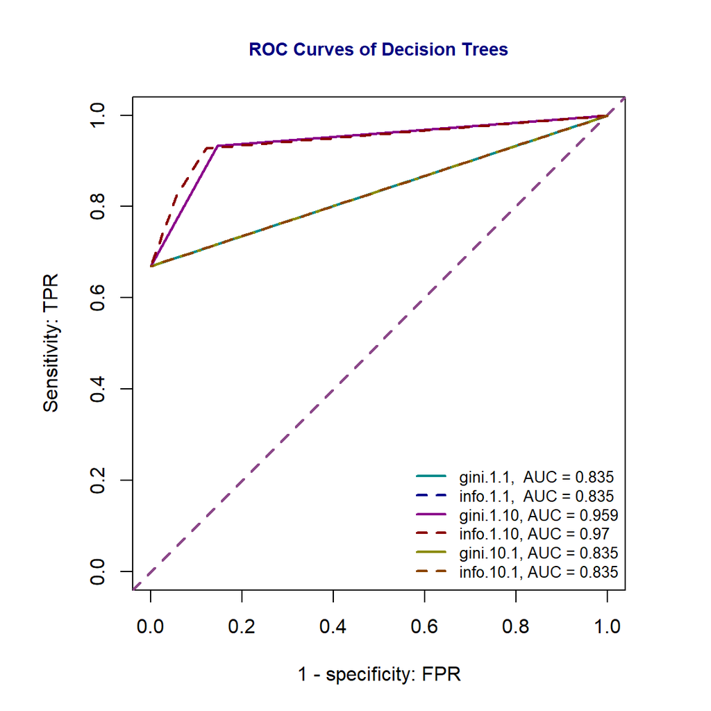

Comparison of ROC curves

# BAGGING Algorithms

- ROC analysis for BAGGING Algorithms

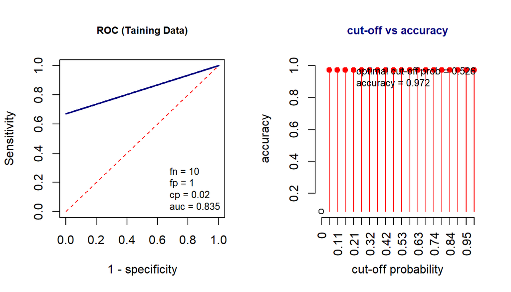

The ROC curve and the plot for optimal cut-off determination

# Comparison

- ROC curves for logistic model and perceptron.

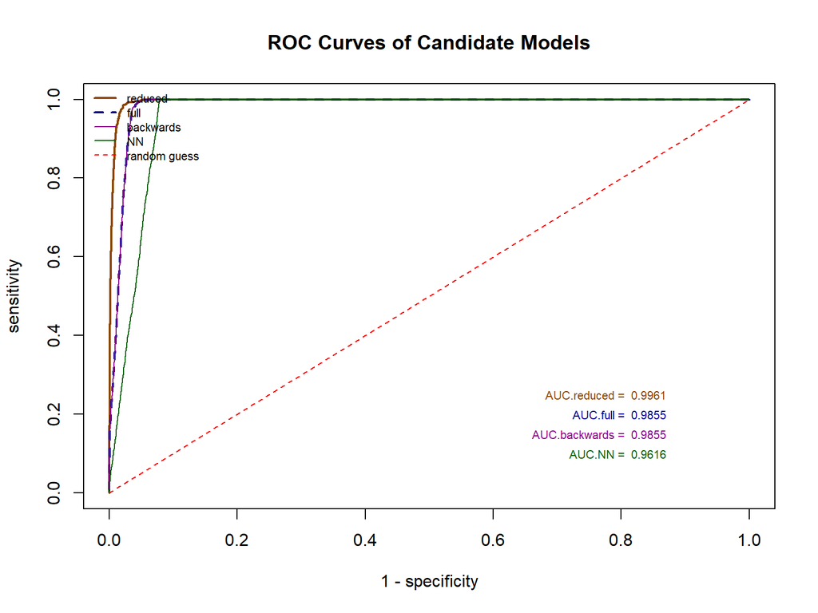

- ROC curve for decision tree.

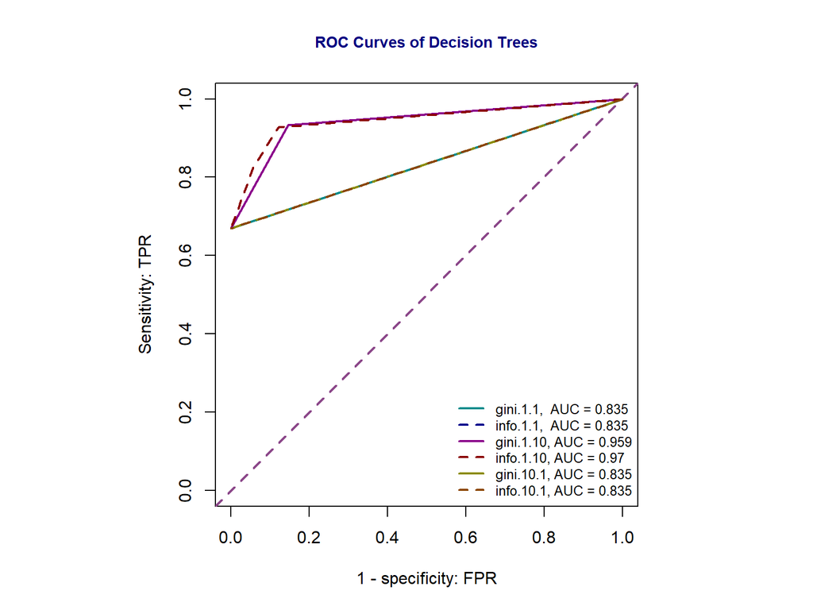

- ROC curve for BAGGING.

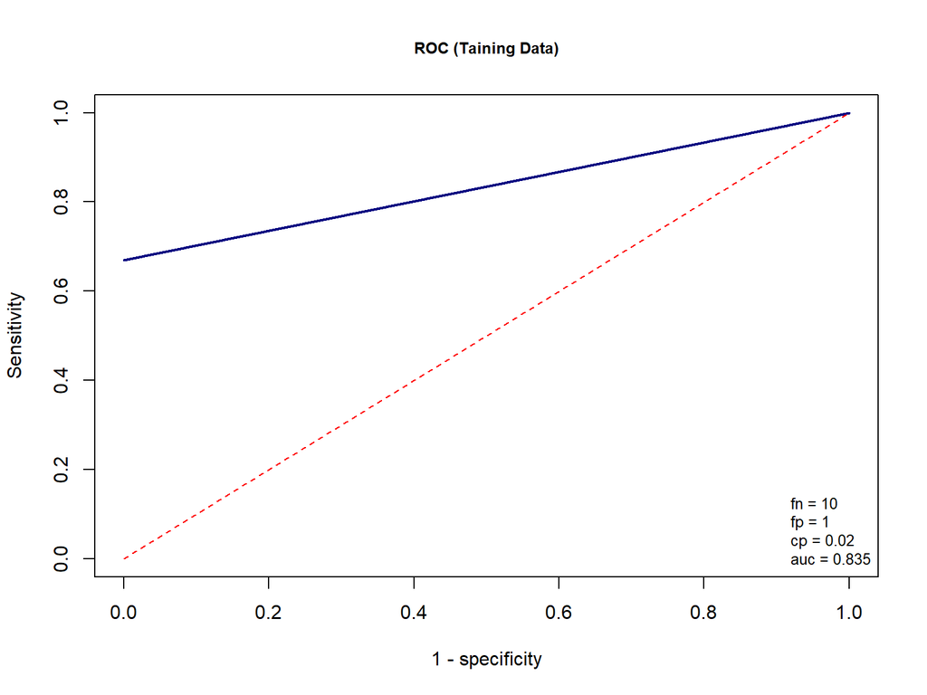

# Conclusion

# Conclusion

Summary table of reduced logistic model

|  | Estimate | Std. Error | z value | Pr(>\|z\|) |
| --- | --- | --- | --- | --- |
| (Intercept) | -13.1031437 | 0.1141369 | -114.80200 | 0 |
| age | 0.0516858 | 0.0008612 | 60.01840 | 0 |
| bmi | 0.0937951 | 0.0020004 | 46.88775 | 0 |
| blood_glucose_level | 0.0332924 | 0.0003783 | 87.99455 | 0 |

- Reduced model: Diabetes ~ Age + BMI + Blood Glucose Level.
- They have positive correlation with diabetes.
- Other variables might be a confounding factors.
- Choose the reduced model for the best model because of higher accuracy.

# Limitation

- Most of the numerical variables are skewed to the right.
- In order to analysis these variables, we need to normalize them by using min-max scaling.